# FigureYa83enrichment

小丫画图出品

2019-3-24

欢迎关注“小丫画图”公众号，同名知识星球等你加入

小丫微信: epigenomics E-mail: figureya@126.com

作者：Haitao Wang

Dr. Haitao Wang: JNU,Guagnzhou => GIBH-CAS,Guagnzhou => BNU,Beijing => IMCB,Singapore => UMAC,Macao => NCCS,Singapore

Email: ht.wang@yahoo.com; wang.haitao@nccs.com.sg

小丫注释、校验

## 需求描述

Enrichment for Molecular Concept Map, to identify significant association within lists of TF genes。

通过转录因子靶基因的集合，用Fisher’s exact test分析转录因子间的coupling（耦合、共调控），在形式上模仿paper里的这种图来展示结果：

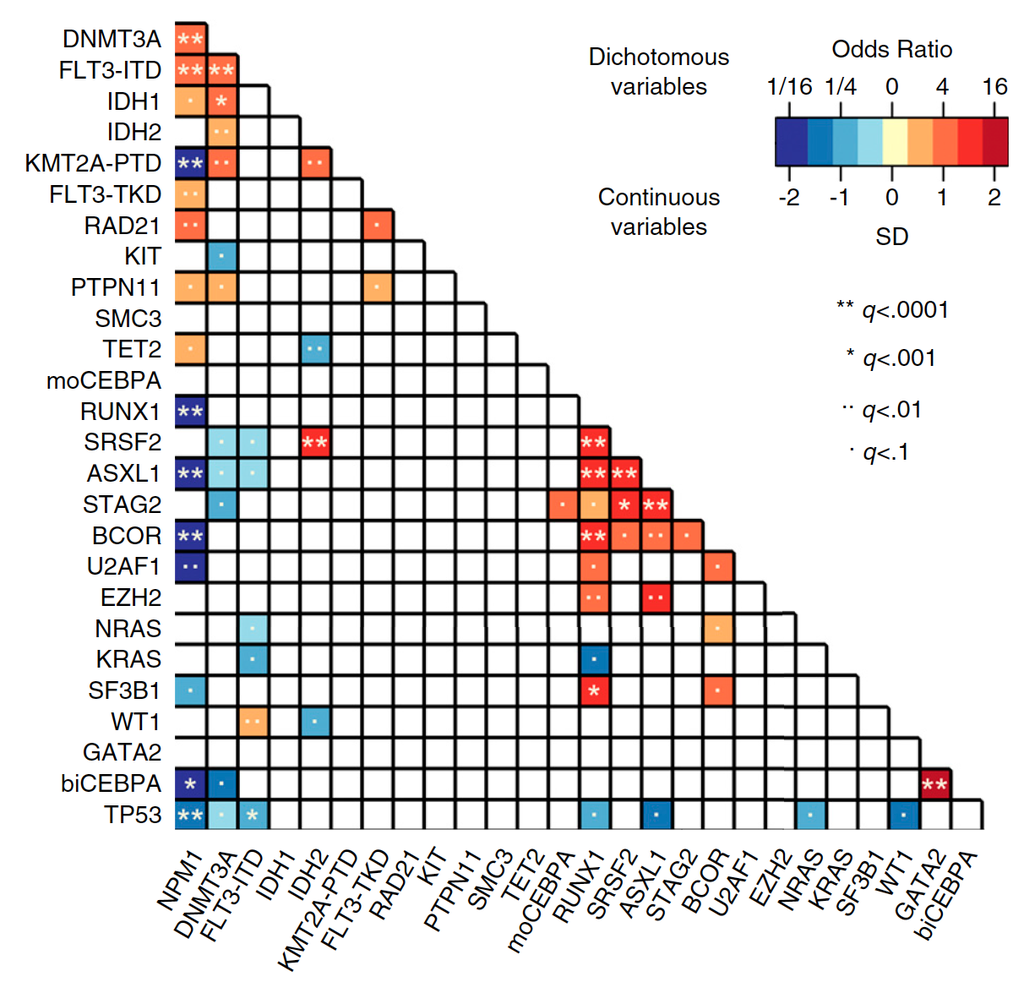

出自http://www.bloodjournal.org/content/128/5/686?sso-checked=true

## 应用场景

分析任意集合之间的关系，例如转录因子之间（示例数据）、差异表达基因跟通路之间、染色质开放跟基因转录之间。

场景一：找转录因子之间的耦合关系（共同调控靶基因），例如示例数据(Interactions.RData)是201个转录因子，以及每个转录因子对应的多个有相互作用的基因。

场景二：差异表达基因在通路里的富集，就把差异表达基因跟通路里的基因都放到Interactions.RData里。例如：

$up_regulated_genes [1] “ZBTB38” “SRA1” “IPO13” “ALX4” “EP300” “CREBBP” “IPO13”

$MAPK_pathway [1] “ESR2” “ZNF688” “BANP” “ISYNA1” “TBC1D7”

场景三：分析染色质开放程度跟基因转录调控之间的关系，就把ATAC-seq peak附近的基因跟差异表达基因都放到Interactions.RData里。例如：

$up_regulated_genes [1] “ZBTB38” “SRA1” “IPO13” “ALX4” “EP300” “CREBBP” “IPO13”

$ATAC-seq_peak [1] “ESR2” “ZNF688” “BANP” “ISYNA1” “TBC1D7”

## 环境设置

使用国内镜像安装包

```r
options("repos"= c(CRAN="https://mirrors.tuna.tsinghua.edu.cn/CRAN/"))
options(BioC_mirror="http://mirrors.ustc.edu.cn/bioc/")
install.packages("rentrez")
```

加载包

```r
library(rentrez)
library(RColorBrewer)
library(corrplot)
library(ggplot2)
library(ggthemes)
source("my_function.R")

Sys.setenv(LANGUAGE = "en") #显示英文报错信息
options(stringsAsFactors = FALSE) #禁止chr转成factor
```

## 输入文件的获得

如果你有自己的相互作用的基因list，保存在Interactions.RData里，就可以跳过这步，直接进入“Fisher’s Exact Test”。

easy_input_TF.csv，此处用201个转录因子的gene symbol，可以替换成你感兴趣的基因的gene symbol，例如差异表达基因、差异表达lncRNA等。

easy_input_bg.csv，背景gene sybol，可以替换成与你感兴趣的基因相对应的背景基因，例如基因组上的全部基因、全部lncRNA等。

```r
TFlist <- read.csv("easy_input_TF.csv", header = T)
head(TFlist)
```

```
##   GeneSym
## 1    ALX1
## 2   TRAF4
## 3   MECOM
## 4  POU1F1
## 5  POU2F1
## 6  POU3F2
```

```r
dim(TFlist)
```

```
## [1] 201   1
```

```r
bglist <- read.table("easy_input_bg.csv", header = T)
head(bglist)
```

```
##     GeneSym
## 1 NPSR1-AS1
## 2     PDZD3
## 3       F12
## 4    HMGCS2
## 5    PRODH2
## 6  C19ORF66
```

```r
dim(bglist)
```

```
## [1] 13216     1
```

### 从NCBI获取基因interaction

用rentrez包获取NCBI gene数据库里的Interactions，即基因与它有相互作用的基因的list，保存到Interactions.RData。The general interactions in this section are provided, without review by Gene staff, by the external sources listed in ftp://ftp.ncbi.nlm.nih.gov/gene/GeneRIF/interaction_sources。详情看这里：https://www.ncbi.nlm.nih.gov/books/NBK3841/#EntrezGene.Interactions

```r
#Download TF related interactions genes from NCBI Gene
#来源：https://github.com/ropensci/rentrez/wiki/Find-genes-known-to-interact-with-a-given-gene
res <- c()
for (i in 1:nrow(TFlist)) {
 output <- print(as.character(TFlist$GeneSym[i]),quote=FALSE)
 gene_search <- entrez_search(db="gene",term=paste0("(",output,"[GENE]) AND (Homo sapiens[ORGN])"))
 # if you just want the interacting genes you can use this function, it's huge Xpath query
 interactions_from_gene <- function(gene_id){
   xmlrec <- entrez_fetch(db="gene", id=gene_id, rettype="xml", parsed=TRUE)
   XML::xpathSApply(xmlrec,
                    "//Gene-commentary[Gene-commentary_heading[./text()='Interactions']]//Other-source[Other-source_src/Dbtag/Dbtag_db[./text()='GeneID']]//Other-source_anchor",
                    XML::xmlValue)
   }
 res1=interactions_from_gene(gene_search$ids)
 res1=toupper(res1)
 res1=list(res1)
 names(res1)=output
 res<- c(res,res1)
}

save(res, file = "Interactions.RData")
```

## Fisher’s Exact Test

Produce a geneset (lists) for hypergeometric test p-value

```r
(load("Interactions.RData"))
```

```
## [1] "res"  "res1"
```

```r
head(res)
```

```
## $ALX1
## [1] "ZBTB38" "SRA1"   "IPO13"  "ALX4"   "EP300"  "CREBBP" "IPO13"
##
## $TRAF4
##   [1] "ESR2"     "ZNF688"   "BANP"     "ISYNA1"   "TBC1D7"   "RBPMS"
##   [7] "TRAF4"    "HGS"      "GOLGA2"   "E7"       "LNX1"     "TAE1"
##  [13] "PSMC3"    "MIA2"     "CATSPER4" "ARNT2"    "RPL14"    "FAT1"
##  [19] "TRAF2"    "RPS6KB1"  "MAGEC2"   "PRMT5"    "CTNNB1"   "AKT1"
##  [25] "TRAF6"    "FAM90A1"  "WWP2"     "UBL4A"    "FAM214B"  "BYSL"
##  [31] "USP7"     "HIP1R"    "HOMEZ"    "REXO1L6P" "PKD1P1"   "KANSL1"
##  [37] "BCL6B"    "UBL4B"    "KRT40"    "FBXL18"   "SPDL1"    "ALKBH4"
##  [43] "WBP11"    "ZNF581"   "GORASP2"  "EXOC7"    "BAHD1"    "WWP1"
##  [49] "MRPL28"   "NOS1AP"   "ZNF3"     "SUMO1"    "TYK2"     "TP53BP2"
##  [55] "QARS"     "KRT31"    "USP15"    "TGFBR2"   "TGFBR1"   "MAP3K7"
##  [61] "SMURF1"   "SMURF2"   "SUZ12"    "BMI1"     "KDM1A"    "CHUK"
```

[output cut: 50 more lines]

```r
# Match and filter geneset by background genelist list size range (number of genes) from 150 - 2000
# 也可以跳过这行，不做筛选
res1 <- GeneSetsFilterByBackground(res,bglist$GeneSym,100,2000)
```

```
## [1] "Processing 1"
## [1] "Processing 2"
## [1] "Processing 3"
## [1] "Processing 4"
## [1] "Processing 5"
## [1] "Processing 6"
## [1] "Processing 7"
## [1] "Processing 8"
## [1] "Processing 9"
## [1] "Processing 10"
## [1] "Processing 11"
## [1] "Processing 12"
## [1] "Processing 13"
## [1] "Processing 14"
## [1] "Processing 15"
```

[output cut: 186 more lines]

```r
names(res1)
```

```
##  [1] "CDC5L"  "AR"     "NR3C1"  "TCF4"   "NKX2-1" "FOXA1"  "CEBPA"
##  [8] "HLF"    "SMAD3"  "TP53"   "LMO2"   "RXRA"   "TCF3"   "MAX"
## [15] "MYC"    "HIF1A"  "RUNX1"  "ESR1"   "SF1"    "HNF4A"  "PPARG"
## [22] "HSF1"   "SMAD1"  "SMAD4"  "REL"    "RELA"   "STAT1"  "STAT3"
## [29] "TBP"    "JUN"    "E2F1"   "RB1"    "YY1"    "PCBP1"  "ATF2"
## [36] "CREB1"  "MIF"    "KAT2B"
```

```r
length(names(res1))
```

```
## [1] 38
```

```r
##########################################################
################# hypergeometric test ####################
##########################################################
# hyper and hyperTest function to caculate enrichment score and its pvalue by using hypergeometric test for each given genelist
# useage ## input 1. the list of GeneSet 2. length of background genes
# useage HyperGeoTest <- hyperTest(GeneSet, length(background.genes))

hyper <- function(X,Y,N,alpha=1){
  K<-length(X)
  M<-length(Y)

  if(K==0 || M ==0){
    return(1)
  }

  both<-length(intersect(X,Y));

  XOnly<-length(setdiff(X,Y));
  YOnly<-length(setdiff(Y,X));
  Fisher.table<-N-both-XOnly-YOnly;
  tab<-matrix(c(Fisher.table,  YOnly, XOnly, both),2,2);
  dimnames(tab)<-list(0:1,0:1);
  f<-fisher.test(tab,alternative="greater");
  pVal<-f$p.value;
  estimate<-f$estimate;
  return(c(pVal,estimate));
}

## s A list of gene vectors.
## N as a number to provide by using length (total background genes).
hyperTest<-function(s, N, alpha=1){
  n<-length(s);
  pVal<-matrix(0,n,n);
  estimate<-matrix(0,n,n);
  for(i in 1:n){
    print(paste("Processing", i));
    for(j in 1:n){
      h<-hyper(s[[i]],s[[j]],N,alpha);
      pVal[i,j]<-h[1];
      estimate[i,j]<-h[2];
    }
  }
  dimnames(pVal)<-list(names(s),names(s));
  dimnames(estimate)<-list(names(s),names(s));
  return(list(pVal=pVal,estimate=estimate));
}

# hypergeometric test p-value
HyperGeoTest <- hyperTest(res1, length(bglist$GeneSym))
```

```
## [1] "Processing 1"
## [1] "Processing 2"
## [1] "Processing 3"
## [1] "Processing 4"
## [1] "Processing 5"
## [1] "Processing 6"
## [1] "Processing 7"
## [1] "Processing 8"
## [1] "Processing 9"
## [1] "Processing 10"
## [1] "Processing 11"
## [1] "Processing 12"
## [1] "Processing 13"
## [1] "Processing 14"
## [1] "Processing 15"
```

[output cut: 23 more lines]

```r
rm(res1)

# Extract estimate value
est <- HyperGeoTest$estimate
# Remove self comparing results
est[est==Inf] = NA
head(est)
```

```
##            CDC5L        AR     NR3C1     TCF4    NKX2-1    FOXA1     CEBPA
## CDC5L         NA  3.863550  4.248266 2.856121 11.040295 5.232450  4.487943
## AR      3.863550        NA 43.441982 7.101735 12.470526 3.869820 22.359570
## NR3C1   4.248266 43.441982        NA 7.081036 13.284762 5.080099 18.562074
## TCF4    2.856121  7.101735  7.081036       NA  5.811142 2.912468  7.437542
## NKX2-1 11.040295 12.470526 13.284762 5.811142        NA 9.229868 17.039875
## FOXA1   5.232450  3.869820  5.080099 2.912468  9.229868       NA  3.979745
##              HLF     SMAD3     TP53     LMO2      RXRA      TCF3       MAX
## CDC5L   3.169418  3.182792 5.348008 1.410756  2.759367  3.477335  4.160574
## AR     15.941096 12.556988 9.575488 3.510401 23.467375  6.482227  8.170637
## NR3C1  18.381000  8.237488 9.739825 2.764671 28.285120  8.538273  7.574791
## TCF4    5.404939  4.972783 3.562689 6.020400  9.014249 42.036257  4.632582
## NKX2-1  7.001059  5.175109 7.085546 2.440483 12.599256  6.736123 11.788987
## FOXA1   3.739449  2.043849 3.583508 2.670126  3.276578  3.719227  3.338337
##             MYC     HIF1A     RUNX1      ESR1      SF1     HNF4A     PPARG
## CDC5L  7.825311  6.976997  9.334971  7.693545 8.703492  4.017469  2.526384
## AR     9.775313 13.273590 14.119858 18.310256 9.430237 40.746472 32.024262
## NR3C1  6.898894 10.846573 12.206371 17.899489 8.673821 22.200304 53.749916
## TCF4   4.231712  6.216561 11.795360  3.656964 8.222044 10.842421  9.190059
## NKX2-1 9.883103 12.078592 14.762273 10.173438 9.143130  8.959040 14.076761
## FOXA1  3.188130  6.197255  5.965641  5.455652 5.682805  7.858494  5.216692
##             HSF1    SMAD1     SMAD4       REL      RELA     STAT1
## CDC5L   5.383577 3.762094  2.436755  1.687793  3.416595  3.889574
## AR     18.441929 7.384391 12.321904  4.604423 14.751460  9.670945
## NR3C1  19.885384 3.806444  8.195187  4.997924 12.558238 14.270941
## TCF4    6.862301 4.983521 11.872698 27.001102  7.012591  4.353871
## NKX2-1  8.430312 5.890880  5.054531  1.707576  4.769331  5.853033
## FOXA1   4.119381 3.000472  3.880162  2.659799  2.972266  3.234197
##            STAT3       TBP       JUN      E2F1       RB1       YY1
## CDC5L   2.524429  4.091757  2.908984  3.773071  5.361544  4.806039
## AR      9.749790 17.352484 17.235190 13.099418 16.248668 13.922414
## NR3C1  14.948694 13.057764 20.607625  7.919415 10.388777 11.047775
## TCF4    6.002617  5.720195  7.829838  4.596118  7.227975  8.846492
## NKX2-1  4.880220  8.689269 12.350773  7.627080  7.776466 12.366526
## FOXA1   2.157497  5.432916  7.029532  5.741940  5.102155  2.647113
##            PCBP1      ATF2     CREB1      MIF     KAT2B
## CDC5L  12.796788  4.152374  2.670440 9.964087  2.100179
## AR      4.238476  7.820590 14.725064 6.213466 11.601629
## NR3C1   3.870597  8.518329 12.835945 3.486807 10.531701
## TCF4    3.684000  3.845332  3.041413 4.031780  8.339682
## NKX2-1  7.808793 10.508262 12.083384 5.338726 10.293283
## FOXA1   7.786948  4.025238  4.507720 4.307134  4.915199
```

```r
# Extract pvalue
p <- HyperGeoTest$pVal
```

借用corrplot做clustring，为后面画图做准备

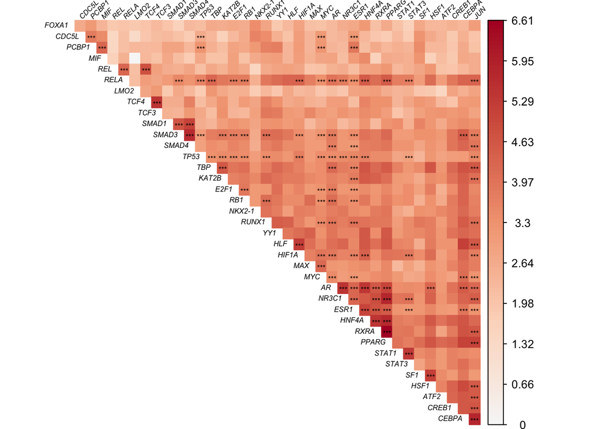

```r
# set color
cols=rev(colorRampPalette(brewer.pal(9,"RdBu"))(199))
#cols=brewer.pal(n=9, name="RdBu")

p1 <- corrplot(as.matrix(log2(est+1)),
         type = "upper", #只显示上三角
         method="color",
         order="hclust",
         hclust.method="ward.D2",
         col=cols,
         tl.col ="black", #文字颜色
         tl.cex = 0.5, #文字大小
         tl.srt =45, #Text label color and rotation
         is.corr = FALSE, #非相关系数矩阵。对于一般的矩阵，必须使用is.corr = FALSE
         diag = F,  #不展示相关系数
         p.mat = as.matrix(p), #p值的矩阵
         sig.level = c(1e-25,1e-35,1e-50), #显著水平
         insig = c("label_sig"), #显著水平以***、**、*表示
         pch.cex = 0.5, #标注的星号*的大小
         font = 3) #斜体
```

## 开始画图

作者提供了三种画法展示以上结果，这里展示画法一，画法二三见压缩包里的2_3_ggplot2.R文件

### 准备工作

前面用corrplot做了聚类，提取顺序；只需要画一半，也就是三角形，需要把另一半变成NA。

```r
# Remove self comparing p vaule
# p[p == 0 ] =NA
p[p < 1.0e-150]=NA #or p[p == 0 ] = NA
p[lower.tri(p)] <- NA

# cluster ordering info by corrplot function
o <- rownames(p1)

# p value reordered by ward.D2 hclust
p <- reorder(p, o)

# get -log10 fdr value
q <- -log10(p.adjust(p, method="fdr"))
# get -log10 p value
p <- -log10(p)
head(p)
```

```
##       FOXA1    CDC5L    PCBP1       MIF       REL      RELA      LMO2
## FOXA1    NA 12.02678 16.48225  3.640976 1.6806030  2.865683 1.3368616
## CDC5L    NA       NA 57.41580 22.663018 1.0592786  6.967326 0.5754358
## PCBP1    NA       NA       NA 34.678648 0.8546105  5.385240 3.6343825
## MIF      NA       NA       NA        NA 0.8346240  4.732614 0.0000000
## REL      NA       NA       NA        NA        NA 33.250952 1.6895222
## RELA     NA       NA       NA        NA        NA        NA 2.4918250
##            TCF4     TCF3     SMAD1     SMAD3     SMAD4      TP53       TBP
## FOXA1  2.246280 2.655459  2.518540  1.490785  3.833323  9.516966  4.790087
## CDC5L  3.899248 4.280294  7.066294  6.952630  2.856333 37.179877  5.596721
## PCBP1  4.838063 4.195044 11.855565 16.721921  5.871606 51.545858  5.631295
## MIF    3.147603 1.554594  5.662832  3.408217  1.413423 15.509674  1.589188
## REL   39.978339 5.613364  5.250885  6.142895  6.266257  7.145988  4.072681
## RELA  11.508411 6.688427 13.298203 27.853311 15.700588 58.599644 27.954777
##           KAT2B      E2F1       RB1     NKX2-1     RUNX1       YY1
## FOXA1  4.755741  8.038257  6.951574 10.1191239  6.733376  1.324165
## CDC5L  1.752320  7.563072 14.293922 22.8691738 23.337891  6.491239
## PCBP1  4.060071 12.609759 11.282900 11.3886966 23.058828 17.648175
## MIF    1.820829  7.665549  2.534646  3.6220774  5.862103  4.837117
## REL    3.474497  7.948579  6.088058  0.5770607  4.702336  4.541666
## RELA  22.736307 28.173071 29.430656  4.6224764 24.129228 22.496096
##             HLF     HIF1A       MAX       MYC        AR     NR3C1
## FOXA1  2.134808 10.489718  2.154522  5.432243  5.099931  5.917352
## CDC5L  2.845684 23.758696  5.688034 45.291005  9.682534  8.284426
## PCBP1  3.482589 19.206829  4.356302 34.776434  8.593851  5.347676
## MIF    2.065460  9.783013  2.889214 12.323184  8.516832  2.493840
## REL    4.164309  8.306707  1.474467  4.339236  5.722008  4.823688
## RELA  23.105805 49.920241 17.481078 34.728413 40.962759 25.136759
##            ESR1     HNF4A       RXRA     PPARG     STAT1     STAT3
## FOXA1 15.659555  6.703015  1.8840316  3.915891  2.308007  1.398402
## CDC5L 50.244448  4.433265  2.4185449  2.011465  5.827263  3.420852
## PCBP1 72.960458  2.746078  5.7358365  3.730684  6.139478  7.449432
## MIF   18.383578  7.139149  0.7664813  3.291242  3.850406  4.553522
## REL    6.410744  4.050237  4.5989340  6.447776  2.897421  4.862747
## RELA  37.431673 27.863572 21.4887073 29.447934 19.822534 28.015195
##             SF1       HSF1      ATF2     CREB1     CEBPA       JUN
## FOXA1  5.726932  2.9183976  3.973064  3.474540  2.256119 11.104280
## CDC5L 19.420908  8.1901934  7.832374  2.480233  4.910298  4.676651
## PCBP1 18.406623  3.9786936  5.468205  2.153742  5.125021  4.369970
## MIF    8.191398  0.6966533  2.545952  1.112511  2.915457  5.188201
## REL    5.140364  6.9396845  2.320882  1.509716  2.018020  5.487482
## RELA   9.243712 22.8573009 11.555218 18.852342 21.279666 45.535875
```

```r
# estimate value reordered by ward.D2 hclust
o <- rownames(p1)
r <- reorder(est,o)
r[lower.tri(r)] <- NA
```

### 画图

```r
pdf("Enrichment_baseplot.pdf", 11, 10)
par(bty="n",
    mar=c(4,4,4,8)+.1, #四周留空
    las=2,# the style of axis labels
    tcl=-.33) #The length of tick marks as a fraction of the height of a line of text

m <- nrow(est)
n <- ncol(est)

# we should check range(est[!est==Inf]) for col and breaks setting
# we should check data distribution hist(est[!est==Inf]) for col and breaks setting

max_value<- range(r[!is.na(r)])[2]
brks<- c(0,seq(1,20,l=10),seq(21,max_value,l=4))
cols2<- rev(colorRampPalette(brewer.pal(9,"RdBu"))(length(brks)-1))

# baseplot for heatmap
image(x=1:n, y=1:m, r, col=cols2, breaks=brks, xaxt="n", yaxt="n", xlab="",ylab="", xlim=c(0, n+4), ylim=c(0, n+1))

# add gene name
mtext(side=2, at=1:n, o, font=3, col="black") #left
mtext(side=3, at=1:n, o, font=3, col="black") #top

# add white border
abline(h=0:n+.5, col="white", lwd=.5)
abline(v=0:n+.5, col="white", lwd=.5)

# add title
#text(x=n/2, y=m+1, "Enrichment based on Fisher's Exact Test (greater)", pos=3)

q_range<- range(q[!is.na(q)])[2]
# significant labels q>50
w = arrayInd(which(q > q_range/2), rep(m,2))
points(w, pch="*", col="black", cex=1)
# significant labels q>35
w = arrayInd(setdiff(which(q > q_range/3),which(q > q_range/2)),rep(m,2))
points(w, pch=3, col="black", cex=1) # "+""
# significant labels q>25
w = arrayInd(setdiff(which(q > q_range/4),which(q > q_range/3)), rep(m,2))
points(w, pch="-", col="black", cex=1)

# set up legend color bar
image(y = 1:16 +6, x=rep(n,2)+c(2.5,3)+1, z=matrix(c(1:16), nrow=1), col=cols2, add=TRUE)

# add legend color bar scale value
brks2 <- round(c(0,seq(1,20,l=10), seq(21,max_value,l=4)))

axis(side = 4, at = seq(1,15) + 6.5,  tcl=-.15, label=brks2, las=1, lwd=.5)

points(x=rep(n,3)+3.5, y=1:3, pch=c("-","+","*"))
text(x=n+2, y=15, "enrichment estimate value",pos=1,srt=90)
mtext(side=4, at=c(1,2,3,4), c("-log10(FDR) > 25","-log10(FDR) > 35","-log10(FDR) > 50","ns"), line=0.2)
dev.off()
```

[figure not shown]